# EC7025 - SFC

## Interest rates impacts

The graphs presented on the paper are based on the model PCEX, which includes expectation on disposable income and wealth. We will first create the model before simulating it.The shock represents an 100 basis point increase in interest rates.

```r
pcex<-sfc.editEqus(pc,list(
  list(var="cons",eq="alpha1*yde+alpha2*v(-1)"),
  list(var="b_h",eq="ve*(lambda0 + lambda1*r - lambda2*(yde/ve))")))
pcex<-sfc.addEqus(pcex,list(
  list(var="yde",eq="yd(-1)",desc="Expected disposable income"),
  list(var="h_d",eq="ve-b_h",desc="Money demand"),
  list(var="ve",eq="v(-1)+yde-cons",desc="Expected disposable income")))
pcex<-sfc.editVar(pcex,var="yd",init=86.48648)
pcex<-sfc.check(pcex)
init = datapc$baseline[56,]
pcex<-sfc.addScenario(model=pcex,vars="r_bar",values=0.035,inits=1960,
                                            ends=2010,starts=init)
datapcex<-simulate(pcex)
```

This replicates plot figure 4.3. p. 112

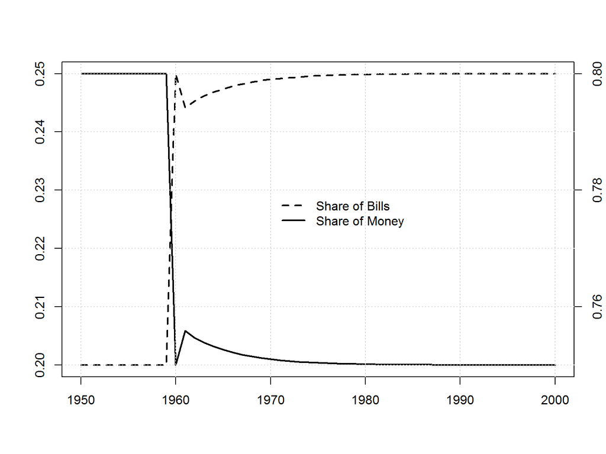

```r
time2=c(1950:2000)
plot(time2, datapcex$scenario[as.character(time2),"h_h"]/
            datapcex$scenario[as.character(time2),"v"],
         type="l",xlab="",ylab="",lty=1,lwd=2)
par(new=T)
plot(time2,datapcex$scenario[as.character(time2),"b_h"]/
            datapcex$scenario[as.character(time2),"v"],
     lty=2, lwd=2,type="l",axes=F,ylab="",xlab="")
axis(4,pretty(c(0.750, 1.1*max(datapcex$scenario[,"b_h"]/
            datapcex$scenario[,"v"],na.rm=T))))
legend(x=1970,y=0.78,legend=c("Share of Bills",
        "Share of Money"),lty=c(2,1),lwd=2,bty="n")
grid()
```

No surprise here, the change in return rates coming from the shock led to a re-allocation between Bills and Money, in favor of the former.

This replicates fig 4.4 . p 113

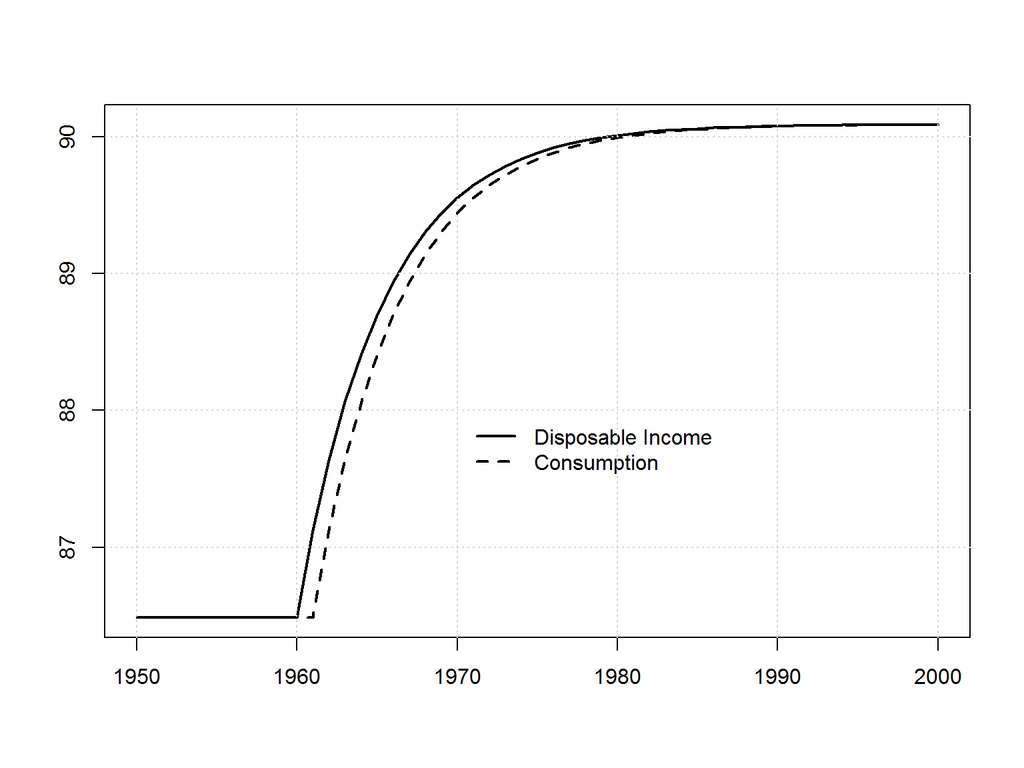

```r
time2=c(1950:2000)
matplot(time2,datapcex$scenario[as.character(time2),c("yd","cons")]
                ,type="l",xlab="",ylab="",lty=1:2,col=1,lwd=2)
legend(x=1970,y=88,legend=c("Disposable Income","Consumption"),
             lwd=c(2,2),lty=c(1,2),bty="n")
grid()
```

These results are more surprising as increased interest rates lead to an increase both in disposable income and consumption. To understand this, one has to bear in mind that increase in interest rates leads to an increase in government spending and thus to an increase in the *fiscal stance* which determines the steady state:

$Y^\star=\frac{G+r \cdot B^{\star}_h \cdot (1-\theta)}{\theta}$

## Endogenous propensities to consume

We change the propensities to consume to incorporate the fact that they might be impacted by interest rates and thus have

$$\begin{equation}
\alpha_1=\alpha_10-\iota\cdot r_{-1} \tag{4.32}
\end{equation}$$

This piece of code shows how to implement this

```r
pc_end<-sfc.addEqus(pcex,list(
  list(var="alpha1",eq="alpha10-iota*r(-1)")))
pc_end<-sfc.addVars(pc_end,list(
  list(var="alpha10",init="0.7",
         desc="Endoegnous propensity to consume - autonomous term"),
  list(var="iota",init="10",
         desc="Endoegnous propensity to consume - interest rate impact")))
pc_end$scenarios<-NULL
pc_end<-sfc.check(pc_end)
datapc_end<-simulate(pc_end)
init = datapc_end$baseline[56,]
pc_end<-sfc.addScenario(model=pc_end,vars="r_bar",values=0.035,
                                                inits=1960,ends=2010,starts=init)
datapc_end<-simulate(pc_end)
```

This replicates plot figure 4.9. p. 123

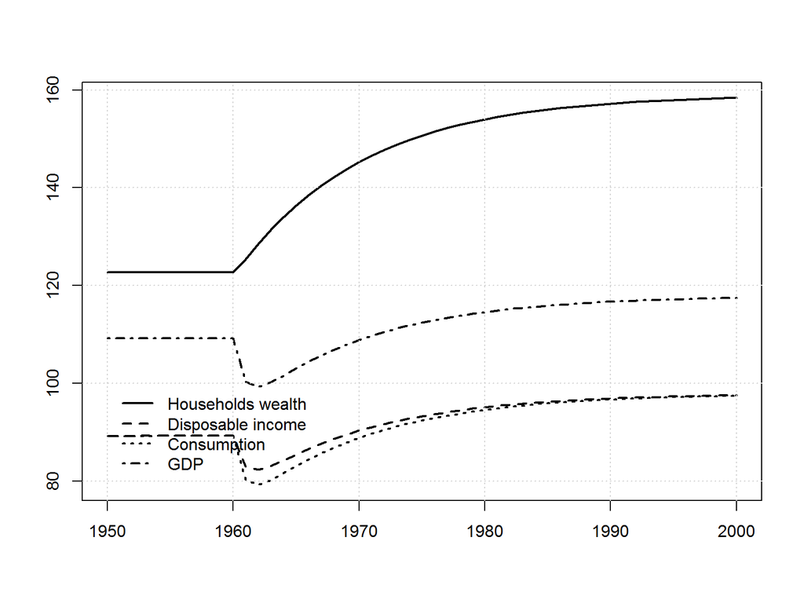

```r
time2=c(1950:2000)
matplot(time2,
     datapc_end$scenario_1[as.character(time2),c("v","yd","cons","y")],
     type="l",xlab="",ylab="",lty=1:4,lwd=2,col=1)
grid()
legend(x=1950,y=100,legend=c("Households wealth","Disposable income",
            "Consumption","GDP"),lty=1:4,lwd=2,bty="n")
```

This shows that now the short-term dynamics display the Keynesian *paradox of thrift* but the long-run steady state still shows a positive impact of interests rates on GDP. The short-run recession is governed by the decrease in the propensity to consumed and is slowly compensated by the increase in wealth (and the increased public debt as a counterpart) leading to the new steady state. The steady state is still driven by the fiscal stance.

This replicates plot figure 4.10. p. 123

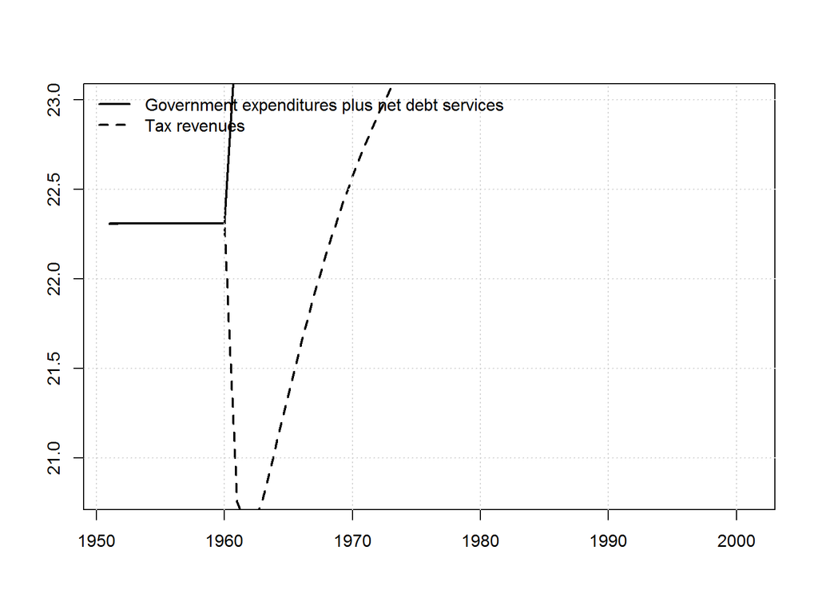

```r
timelag=c(1950:2000)
time2=c(1951:2001)
plot(time2,
     datapc_end$scenario_1[as.character(time2),c("g")]+
            datapc_end$scenario_1[as.character(timelag),c("r")]*
            datapc_end$scenario_1[as.character(timelag),c("b_s")]-
            datapc_end$scenario_1[as.character(timelag),c("r")]*
            datapc_end$scenario_1[as.character(timelag),c("b_cb")],
     type="l",xlab="",ylab="",lty=1:4,lwd=2,col=1,ylim=c(20.8,23))
lines(time2,datapc_end$scenario_1[as.character(time2),"t"],type="l",xlab="",
            ylab="",lty=2,lwd=2)
grid()
legend("topleft",legend=c("Government expenditures plus net debt services",
            "Tax revenues"),lty=1:4,lwd=2,bty="n")
```

## Debt to GDP at the steady state

$$\begin{equation}
\frac{V^\star}{Y^\star}=\frac{\frac{1-\alpha_1}{\alpha_2}}{1+\left[\frac{\theta}{1-\theta}\right]-r\cdot \left[(\lambda_0+\lambda_1\cdot r)\cdot \frac{1-\alpha_1}{\alpha_2}-\lambda_2\right]}\tag{4.33}
\end{equation}$$

The Maastricht treaty: The reference values referred to […] are: - 3% for the ratio of the planned or actual government deficit to gross domestic product at market - 60% for the ratio of government debt to gross domestic product at market prices.

# Liquidity Preferences and model LP

## Value of perpetuity, interest rates, exepcted returns and capital gains

The value of a financial asset is supposed to reflect the net present value of future cash flows. Thus for a long-term bond who is never redeemed, the price $p_{bL}$ of the bond is given by

$p_{bL} = \sum \frac{1}{(1+r_{bL})^t} = \frac{1}{r_{bL}}$

Return rate of an asset is equal to both the yield (interests, dividends) and the capital gains normalized to the nominal value of the asset. In the case of a long-term bond:

$Rr_{bL} = r_{bL}(-1)+\frac{\Delta p_{bL}}{p_{bL}(-1)} = \frac{1+p_{bL}-p_{bL}(-1)}{p_{bL}(-1)}$

However, what matter for the households when making their decision is the expected price of bonds $p_{bL}^e$, given the current price of bonds. This leads to the *pure expected rate of return*.

$PERr_{bL} = r_{bL} + \frac{p^e_{bL}-p_{bL}}{p_{bL}}$

Because expectation are not followed by everyone, households migh incorporate a weight $\xi$ into their expectation formation. This leads to the *expected return rate*

$ERr_{bL} = r_{bL} + \xi \frac{p^e_{bL}-p_{bL}}{p_{bL}}$

The change in prices of bonds leads to capital gains which is one of two parts of the change in nominal value of financial assets. More precisely:

$$\begin{align*}
\Delta (p_{BL}\cdot BL) &=\left(p_{bL} \cdot BL\right) - \left(p_{bL}(-1) \cdot BL(-1)\right)\\
&= p_{BL} \cdot BL-p_{BL}\cdot BL(-1) + p_{BL}\cdot BL(-1)-p_{bL}(-1) \cdot BL(-1)\\
&= p_{BL} \left( BL-BL(-1)\right) + BL(-1) \left(p_{BL}-p_{BL}(-1)\right)\\
&= p_{BL} \cdot \Delta BL+ BL(-1)\cdot \Delta p_{BL}
\end{align*}$$

Thus total changes in nominal values of an asset is equal to the quantity of assets bought (or sold) at the current price ($p_{BL} \cdot \Delta BL$) and to the capital gains (or losses) made on the stock of assets held at the beginning of the period ($BL(-1)\cdot \Delta p_{BL}$)

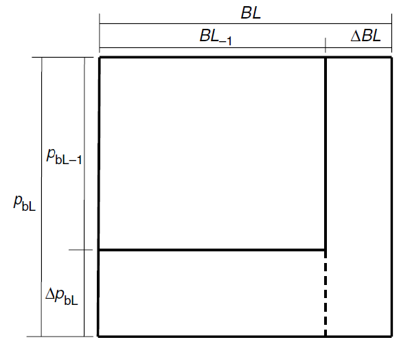

Ostergaard diagram

## Balance Sheet

|  | Households | Production | Government | Central Bank | Sum |
| --- | --- | --- | --- | --- | --- |
| Money | +H |  |  | -H | 0 |
| Bills | +Bh |  | -B | +Bcb | 0 |
| Bonds | +BL.pbL |  | -BL.pbL |  | 0 |
| Net worth | -V |  | +V |  | 0 |
| Sum | 0 | 0 | 0 | 0 | 0 |

## Transaction Flow Matrix

|  | Households | Production | Government | Central Bank | Sum |
| --- | --- | --- | --- | --- | --- |
| Consumption | -C | +C |  |  | 0 |
| Gov. Exp. |  | +G | -G |  | 0 |
| Income = GDP | +Y | -Y |  |  | 0 |
| Interests on bills | +rb(-1)*Bh(-1) |  | -rb(1)*B(-1) | +rb(-1)*Bcb(-1) | 0 |
| Interests on bonds | +BL(-1) |  | -BL(-1) |  | 0 |
| CB profits |  |  | +r(-1)*Bcb(-1) | -r(1)*Bcb(-1) | 0 |
| Taxes | -T |  | +T |  | 0 |
| Change in Money | -$\Delta$ H |  |  | +$\Delta$ H | 0 |
| Change in Bills | -$\Delta$ Bh |  | +$\Delta$ B | -$\Delta$ Bcb | 0 |
| Change in Bonds | -$\Delta$ BL.pbL |  | +$\Delta$ BL.pbL |  | 0 |
| Sum | 0 | 0 | 0 | 0 | 0 |
| *Memo: Capital gains* | -$\Delta$ pbL.BL(-1) |  | +$\Delta$ pbL.BL(-1) |  | 0 |

## Equation list

```r
# MODEL
# Determination of output - eq. 5.1
y = cons + g
# Regular disposable income - eq. 5.2
yd_r = y - t + r_b(-1)*b_h(-1) + bl_h(-1)
# Tax payments - eq. 5.3
t = theta*(y + r_b(-1)*b_h(-1) + bl_h(-1))
# Wealth accumulation - eq. 5.4
v = v(-1) + (yd_r - cons) + cg
# Capital gains on bonds - eq. 5.5
cg = (p_bl-p_bl(-1))*bl_h(-1)
# Consumption function - eq. 5.6
cons = alpha1*yd_r_e + alpha2*v(-1)
# Expected wealth - eq. 5.7
v_e = v(-1) + (yd_r_e - cons) + cg
# Cash money - eq. 5.8
h_h = v - b_h - p_bl*bl_h
# Demand for cash - eq. 5.9
h_d = v_e - b_d - p_bl*bl_d
# Demand for government bills - eq. 5.10
b_d = v_e*(lambda20 + lambda22*r_b - lambda23*er_rbl - lambda24*(yd_r_e/v_e))
# Demand for government bonds - eq. 5.11
bl_d = v_e*(lambda30 - lambda32*r_b + lambda33*er_rbl - lambda34*(yd_r_e/v_e))/p_bl
# Bills held by households - eq. 5.12
b_h = b_d
# Bonds held by households - eq. 5.13
bl_h = bl_d
# Supply of government bills - eq. 5.14
b_s = b_s(-1) + (g + r_b(-1)*b_s(-1) + bl_s(-1)) - (t + r_b(-1)*b_cb(-1)) -p_bl*(bl_s-bl_s(-1))
# Supply of cash - eq. 5.15
h_s = h_s(-1) + b_cb - b_cb(-1)
# Government bills held by the central bank - eq. 5.16
b_cb = b_s - b_h
# Supply of government bonds - eq. 5.17
bl_s = bl_h
# Expected rate of return on bonds - eq. 5.18
er_rbl = r_bl+chi*(p_bl_e - p_bl)/p_bl
# Interest rate on bonds - eq. 5.19
r_bl = 1/p_bl
# Expected price of bonds - eq. 5.20
p_bl_e = p_bl
# Expected capital gains - eq. 5.21
cg_e = chi*(p_bl_e - p_bl)*bl_h
# Expected regular disposable income - eq. 5.22
yd_r_e = yd_r(-1)
# Interest rate on bills - eq. 5.23
r_b = r_bar
# Price of bonds - eq. 5.24
p_bl = p_bl_bar
```

Let’s have a look at the graph of model LP

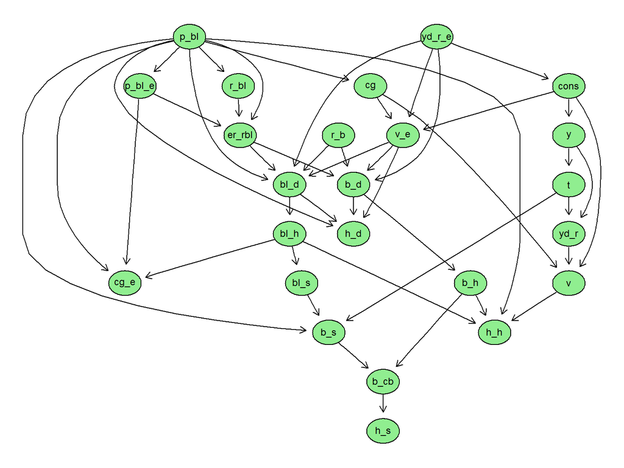

```r
lp<-sfc.model(fileName="LP.txt",modelName="Model Liquidity Preference")
plot.dag(lp)
```

## The adding up of the portfolio behavior

The vertical conditions state that the sum of the exogenous components sums to 1, i.e. you cannot allocate more than the wealth and that the effect of the various return rates and disposable income are substracting the holding of one asset to allow the increase of the holding of another.

$$\begin{align}
\lambda_{10} + \lambda_{20} + \lambda_{30} &= 1 \tag{ADUP.1}\\
\lambda_{11} + \lambda_{21} + \lambda_{31} &= 0 \tag{ADUP.2}\\
\lambda_{12} + \lambda_{22} + \lambda_{32} &= 0 \tag{ADUP.3}\\
\lambda_{13} + \lambda_{23} + \lambda_{33} &= 0 \tag{ADUP.4}\\
\lambda_{14} + \lambda_{24} + \lambda_{34} &= 0 \tag{ADUP.5}
\end{align}$$

The horizontal conditions, added by Godley (1996) state that the impact of an increase in the ‘own rate’ of an asset should be equal to the impact of a fall in all the other rates.

$$\begin{align}
\lambda_{11} &= - \left( \lambda_{12} + \lambda_{13}\right) \tag{ADUP.6}\\
\lambda_{22} &= - \left( \lambda_{21} + \lambda_{23}\right) \tag{ADUP.7}\\
\lambda_{33} &= - \left( \lambda_{31} + \lambda_{32}\right) \tag{ADUP.8}
\end{align}$$

Other authors propose the symetry conditions that state that an increase in the return rate of one asset A will have the same impact on the holding of asset B as the increase in the return rate of asset B will have on the holding of asset A

$$\begin{align}
\lambda_{12} &= \lambda_{21} \tag{ADUP.9}\\
\lambda_{13} &= \lambda_{31} \tag{ADUP.10}\\
\lambda_{23} &= \lambda_{32} \tag{ADUP.11}
\end{align}$$

Note that vertical + symetry imply automatically horizontal but that vertical + horizontal does not necessarily imply symetry.

## Higher interest rates

The first scenario run looks at the impact of interest rates (short- and long-term) on real demand. We assume that the government increases short-term rates from 3% to 4% and the long-term rate from 5% to 6.66%. We assume that this increase is cmpletely unexcpected and that the Treasury is believed in that no other change will occur.

```r
lp<-sfc.addScenario(model=lp,vars=list(c("r_bar","p_bl_bar")),values=list(c(0.04,15)),
                            inits=1960,ends=2000)
datalp<-simulate(lp)
```

This replicates plot figure 5.2. p. 152

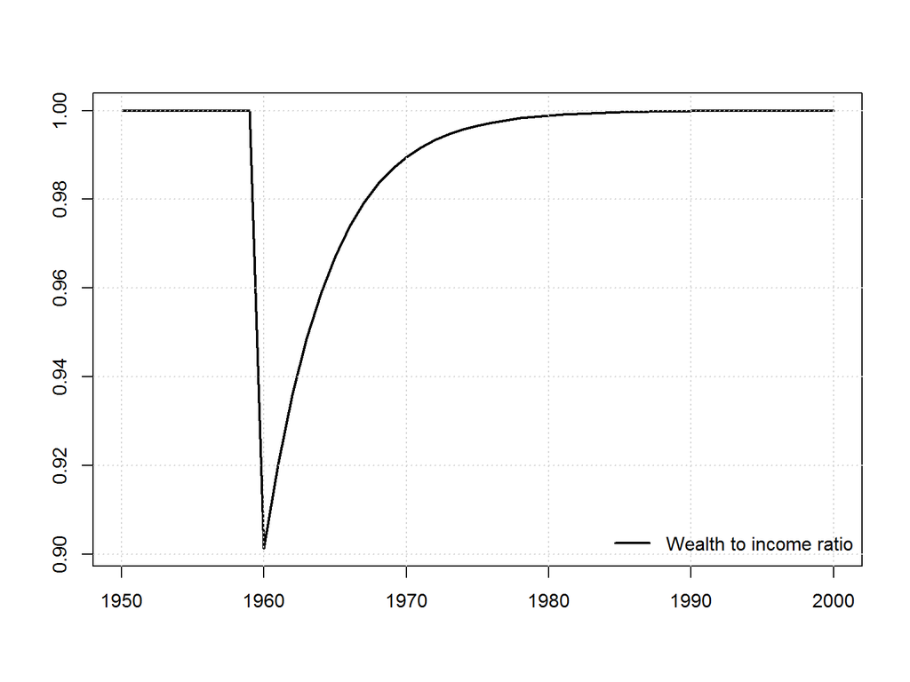

```r
time2=c(1950:2000)
plot(time2, datalp$scenario_1[as.character(time2),"v"]/
            datalp$scenario[as.character(time2),"yd_r"],
         type="l",xlab="",ylab="",lty=1,lwd=2)
legend("bottomright",legend=c("Wealth to income ratio"),lty=c(1),lwd=2,bty="n")
grid()
```

We see that the increase in long-term interest rate leads to capital losses on bonds, leading to a decrease in welath to income ratio. However because interest rates have increase, households have now a higher disposable income leading to a replenishing of their wealth. Note that as in model PC, the steady state GDP is given by

$Y^\star=\frac{G+\left(r_B\cdot B^{\star}_h+BL_S^\star\right) \cdot (1-\theta)}{\theta} = \frac{G_{NT}}{\theta}$

This replicates plot figure 5.3. p. 152

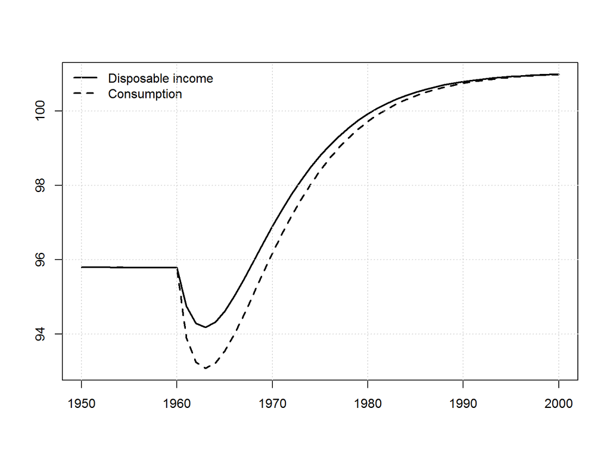

```r
time2=c(1950:2000)
matplot(time2, datalp$scenario_1[as.character(time2),c("yd_r","cons")],
         type="l",xlab="",ylab="",lty=c(1,2), col=1,lwd=2)
legend("topleft",legend=c("Disposable income","Consumption"),lty=c(1,2),lwd=2,bty="n")
grid()
```

This replicates plot figure 5.4. p. 153

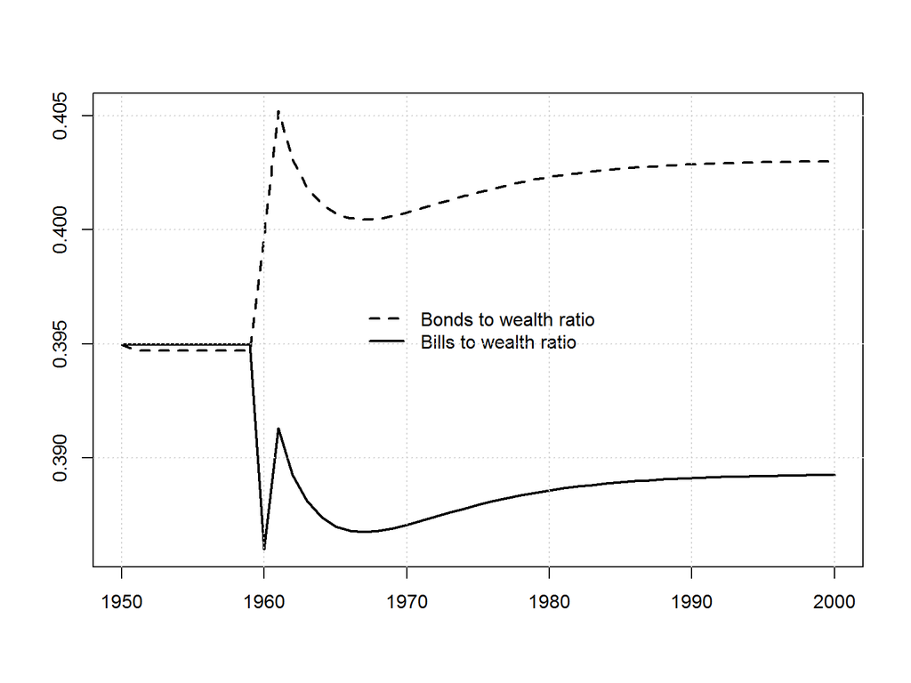

```r
time2=c(1950:2000)
matplot(time2, cbind(datalp$scenario_1[as.character(time2),c("b_h")],
            datalp$scenario_1[as.character(time2),c("p_bl")]*
            datalp$scenario_1[as.character(time2),c("bl_h")])/
                datalp$scenario_1[as.character(time2),c("v")],
         type="l",xlab="",ylab="",lty=c(1,2), col=1,lwd=2)
legend("center",legend=c("Bonds to wealth ratio","Bills to wealth ratio"),
        lty=c(2,1),lwd=2,bty="n")
grid()
```

## Introducing household liquidity

In order to introduce liquidity preferences, we need to modify the model. The first modification is to change the expectation on bonds price to include (i) a learning element and (ii) a stochastic term. Because expectation are going to play a role, we also need to modify the price equation for bonds such that it now reflects a corridor approach to bond pricing. The assumption is thus that the Treasury will try to pin down the price of bonds but only to a certain extent. If the demand is too large (or too low) the treasury will let prices (and interest) float. We assume that the government aims at a certain debt strcuture in terms of maturity.

```r
#Adding the equations
lp2<-sfc.addEqus(lp,list(
    list(var="z1",equ = "TP>top"),
    list(var="z2",equ = "TP<bot"),
    list(var="TP",equ = "(bl_h(-1)*p_bl(-1))/(bl_h(-1)*p_bl(-1)+b_h(-1))")))
#Adding the parameters
lp2<-sfc.addVars(lp2,list(
    list(var="betae",init=0.5),
    list(var="beta",init=0.01),
    list(var="add",init=0),
    list(var="top",init=0.495),
    list(var="bot",init=0.505)
))
#Adding initial values to the endogenous variables that have lags
lp2<-sfc.editEnd(lp2,var="p_bl_e", init=20)
lp2<-sfc.editEnd(lp2,var="p_bl", init=20)
#Modifying the existing equations
lp2<-sfc.editEqus(lp2,list(
    list(var="p_bl", eq="(1+z1*beta-z2*beta)*p_bl(-1)"),
    list(var="p_bl_e",equ = "p_bl_e(-1)-betae*(p_bl_e(-1) - p_bl) + add")))
#Removing all existing scenarios (coming from LP)
lp2$scenarios<-NULL
#Checking that the model is complete
lp2<-sfc.check(lp2,fill=F)
#Adding the scenario
lp2<-sfc.addScenario(model=lp2,vars=list(c("r_bar")),values=list(c(0.035)),inits=1960,
                                            ends=2000)
lp2<-sfc.addScenario(model=lp2,vars=list(c("add")),values=list(c(-3)),inits=c(1955),
                                            ends=1955)
```

Let’s have a look at the graph of model LP2

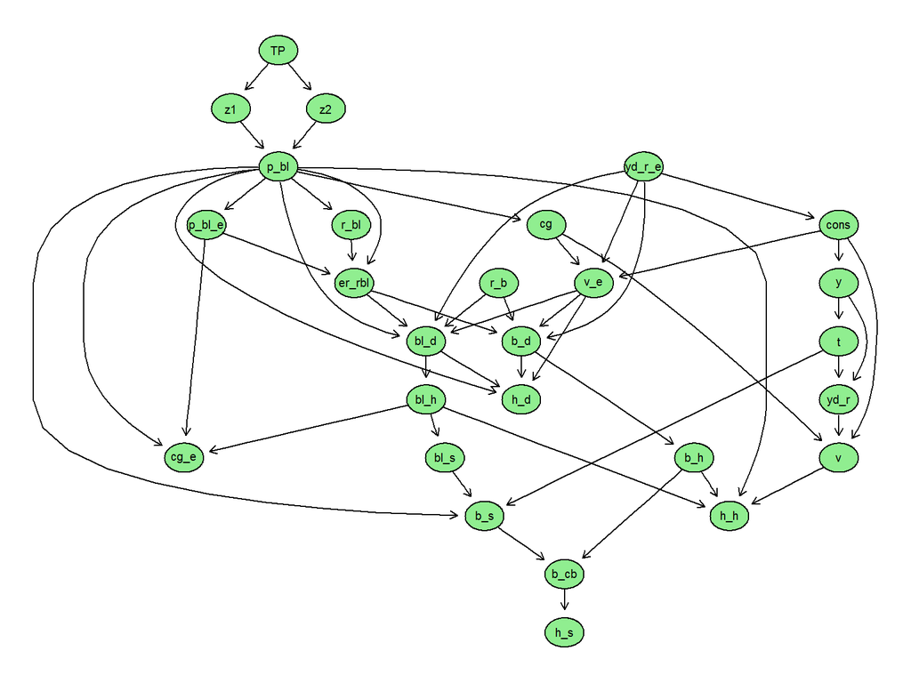

```r
plot.dag(lp2)
```

We are now ready to simulate the model

```r
datalp2<-simulate(lp2)
```

This replicates plot figure 5.5. p. 156

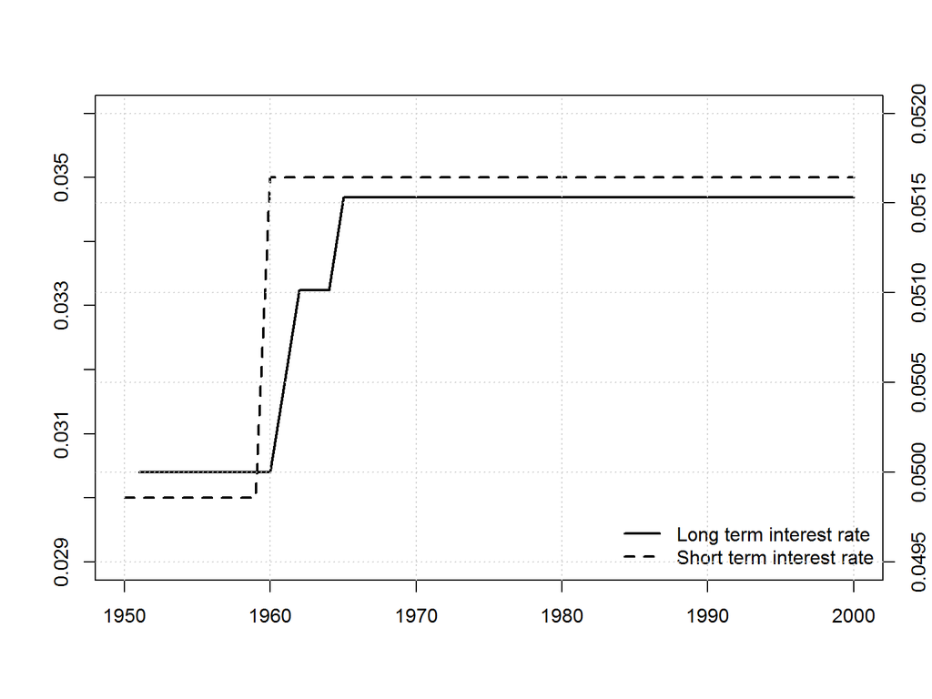

```r
time2=c(1950:2000)
plot(time2,datalp2$scenario_1[as.character(time2),"r_b"],
     lty=2, lwd=2,type="l",ylab="",xlab="",ylim=c(0.029,0.036))
par(new=T)
plot(time2, datalp2$scenario_1[as.character(time2),"r_bl"],
         type="l",xlab="",axes=F,ylab="",lty=1,lwd=2,ylim=c(0.0495,0.052))
axis(4,pretty(c(0.0495,0.052)))
legend("bottomright",legend=c("Long term interest rate",
        "Short term interest rate"),lty=c(1,2),lwd=2,bty="n")
grid()
```

This replicates plot figure 5.6. p. 156

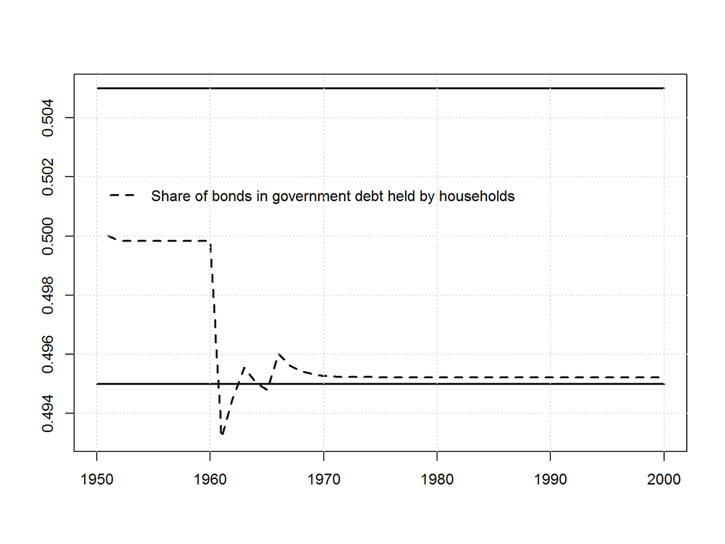

```r
time2=c(1950:2000)
matplot(time2, datalp2$scenario_1[as.character(time2),c("TP","bot","top")],
         type="l",xlab="",ylab="",lty=c(2,1,1), col=1,lwd=2)
legend(x=1950,y=0.502,legend=c("Share of bonds in government debt held by households"),
             lty=c(2),lwd=2,bty="n")
grid()
```

Let’s add a second scenario by which there is an expected fall in the price of long-term bonds.

```r
lp2<-sfc.addScenario(model=lp2,vars=list(c("add")),values=list(c(-3)),inits=c(1955),
                                            ends=1955)
datalp2<-simulate(lp2)
```

This replicates plot figure 5.7. p. 157

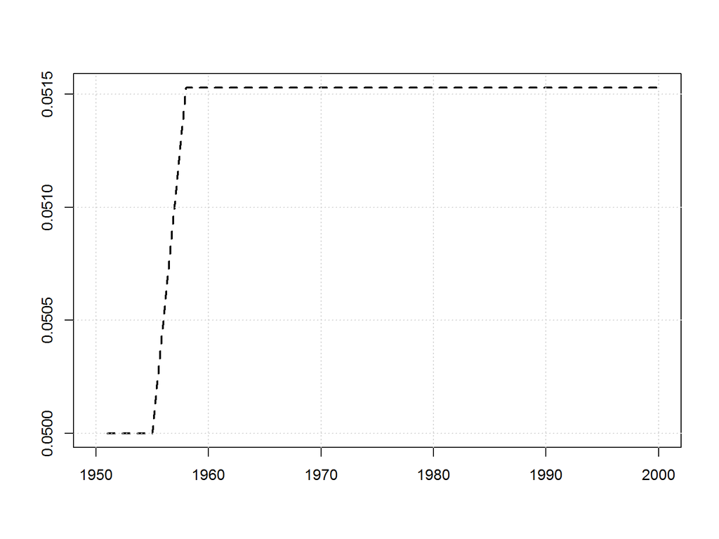

```r
time2=c(1950:2000)
matplot(time2, datalp2$scenario_2[as.character(time2),c("r_bl")],
         type="l",xlab="",ylab="",lty=c(2,1,1), col=1,lwd=2)
legend(x=1950,y=0.502,legend=c("Share of bonds in government debt held by households"),
             lty=c(2),lwd=2,bty="n")
grid()
```

This replicates plot figure 5.8. p. 158

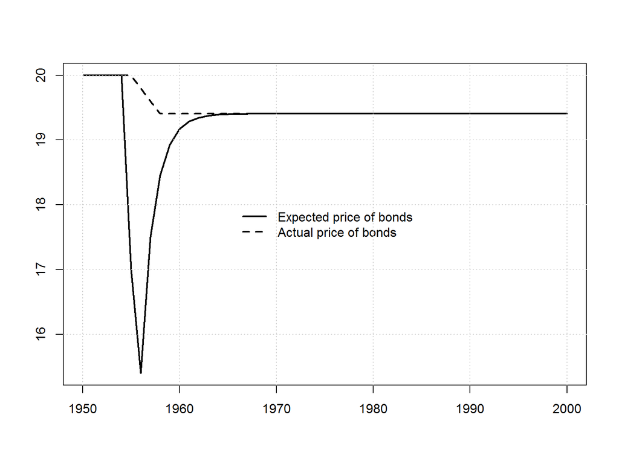

```r
time2=c(1950:2000)
matplot(time2, datalp2$scenario_2[as.character(time2),c("p_bl_e","p_bl")],
         type="l",xlab="",ylab="",lty=c(1,2), col=1,lwd=2)
legend("center",legend=c("Expected price of bonds","Actual price of bonds"),
             lty=c(1,2),lwd=2,bty="n")
grid()
```

This replicates plot figure 5.9. p. 158

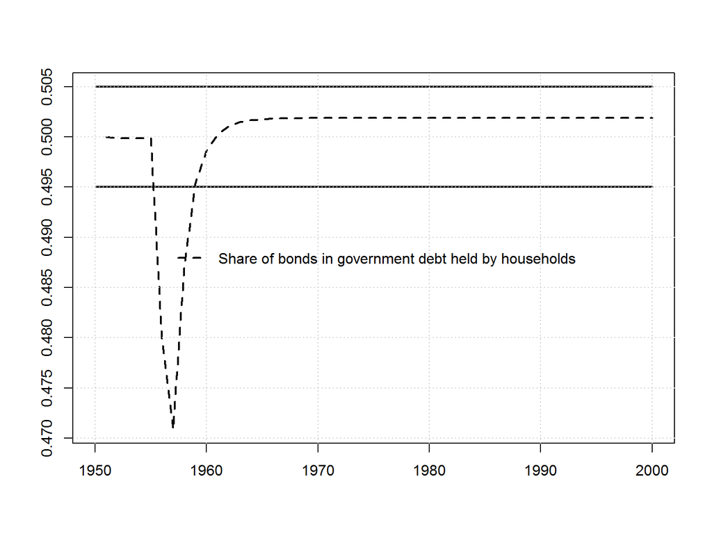

```r
time2=c(1950:2000)
matplot(time2, datalp2$scenario_2[as.character(time2),c("TP","bot","top")],
         type="l",xlab="",ylab="",lty=c(2,1,1), col=1,lwd=2)
legend("center",legend=c("Share of bonds in government debt held by households"),
             lty=c(2),lwd=2,bty="n")
grid()
```

# Modelling the firm: price, investment and profits

## The role of banks: credit creation and investment

- Firms will always have an investment function determinin the desired level of production capacity.
  - Model BMW: $K^T=\kappa \cdot Y_{-1}$
- However, the realisation of investment might be constrained by banks credit, leading to an eventual different between desired investment and actual investment.
  - Model BMW: $I_d = \gamma \cdot (K^T-K_{-1})+DA$ where $\gamma$ can be interpreted as the outcome between firms and banks interactions.

## Functional income distribution

- The usual way to distribute income is between wage and profits (i.e. looking at wage share and profit share).
  - It is however often forgotten that profits are then decomposed further between different type of profits: retained earnings and distributed dividends.
  - But that’s not the end of the story: we can disaggregate even further profits between gross profits and net profits, the difference being 1. interest payments, 2. taxes and 3. capital amortisation
  - It is usually the net profits that are then distributed between retained earnings and dividends.
- In model BMW: depreciation allowances (amortisation) are accounted for explicitely ($DA= \delta.K_{-1}$), so are interest payments. We thus have the following functional distribution of income: $Y=WB+r_{l,-1}\cdot L_{-1} + DA$
  - Note that in this case, the wage bill is endogenous since both interests payments and depreciation depend only on past values

## Consumption function

- In model BWM, tyhe consumption function contains an autonomous term: $C = \alpha_0+\alpha_1\cdot YD + \alpha_2 \cdot M_{-1}$.
  - The autonomous term plays an important role in the dynamics of the model as it “kick-starts” the model. It plays the same role as government expenditures in the previous model we’ve seen.

## Steady state of BMW

- Let’s do it manualy, starting from the list of equations:

```r
#Supply of consumption goods - eq. 7.1
 c_s = c_d
#Supply of investment goods - eq. 7.2
 i_s = i_d
#Supply of labour - eq. 7.3
 n_s = n_d
#Transactions of the firms
#GDP - eq. 7.5
 y = c_s + i_s
#Wage bill - eq. 7.6
 wb_d = y - r_l(-1)*l_d(-1) - af
#Depreciation allowances - eq. 7.7
 af = delta*k(-1)
#Demand for bank loans - eq. 7.8
 l_d = l_d(-1) + i_d - af
#Transactions of households
#Disposable income - eq. 7.9
 yd = wb_s + r_m(-1)*m_h(-1)
#Bank deposits held by households - eq. 7.10
 m_h = m_h(-1) + yd - c_d
#The wage bill
#"Supply" of wages - eq. 7.13
 wb_s = w*n_s
#Labour demand - eq. 7.14
 n_d = y/pr
#Wage rate - eq. 7.15
 w = wb_d/n_d
#Household behaviour
#Demand for consumption goods - eq. 7.16
 c_d = alpha0 + alpha1*yd + alpha2*m_h(-1)
#The investment behaviour
#Accumulation of capital - eq. 7.17
 k = k(-1) + i_d - da
#Depreciation allowances - eq. 7.18
 da = delta*k(-1)
#Capital stock target - eq. 7.19
 k_t = kappa*y(-1)
# below is an additional equation I've defined to get output to capital ratio as in figure 7.4, the model will run even without equation
OCR = y/k(-1)
#Demand for investment goods - eq. 7.20
 i_d = gamma*(k_t - k(-1)) + da
```

- Important points to discuss:
  - Role of autonomous consumption
  - The existence of non-negative GDP steady state
  - The equality between capital stock and wealth

## Out of equilibrium values

- To do so, let’s have a look at the graph representation of BMW:

```r
BMW<-sfc.model("BMW.txt")
```

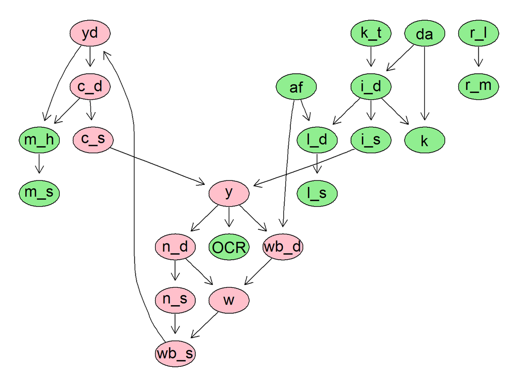

```r
plot.dag(BMW)
```

- We need to solve the pink cycle and express Y (and K) as a function of only lagged variables.

## Stability

- Very brief intro because stability analysis of difference system is much more complicated than for differential systems (will be covered by Devrim in the second part of the semester).
- The stability of a system of equations $z_t = A \cdot z_{t-1} + c$ can be analysed via the trace, determinant and discriminant of A
  - trace = sum of diagonal terms, for 2x2 matrix: $tr_A = a_{11}+a_{22}$
  - determinant, for a 2x2 matrix: $det_A = |A| = a_{11}\cdot a_{22} - a_{21}\cdot a_{12}$
  - discriminat: $\Delta = tr_A^2+4\cdot det_A$
- Necessary condition for stability is that tyeh absolute value of the determinant is smaller than 1
- If this is respected, then either the determinant is positive or if it is negative, the trace has to be smaller than 2 if and only if $-det_a<1-|tr_A|$.
- We won’t go in the details, but the analysis highlight some important characteristics:
  - the system will converge provided the marginal propensity to save is higher than the marginal propensity to invest

## More on profits and inventories

- Inventories are fundamental for the working of a firm in terms of production smoothing, response to sudden changes in demand and dealing with uncertainty. They are very much related to the notion of time in SFC (and other types of post-Keynesian) models. Time is historical, based on past observation and projected in the future by expectations, on the contrary of mainstream models where the future is pulled in the present.
- Example of a current account matrix for firms

| Components | Firms Current account | Firms Capital account |
| --- | --- | --- |
| Sales | $+S$ |  |
| Change in the value of inventories | +$\Delta IN$ | -$\Delta IN$ |
| Wages | $-WB$ |  |
| Interest on loans | $-r_{l-1} L_{-1}$ |  |
| Entrepreneurial profits | $-F$ |  |
| Change in loans | $+\Delta L$ |  |
| Sum | 0 | 0 |

- Entrepreneurial vs total profits
  - Entrepreneurial profits: $F=S-(WB-\Delta IN + r_{l,-1} IN_{-1})$
  - Total profits: $F=S-(WB-\Delta IN)$
- Historical wage costs vs total historic costs
  - Historical wage costs: $HWC = (WB-\Delta IN)$
  - Total istorical costs: $HC = (WB-\Delta IN)+r_{l,-1} IN_{-1}$
- We can show that profits can always be expressed as a fraction of historical costs: $F= \phi' HC$, implying that sales can also be expressed as a function of historical costs only
  - $S = F + HC
  - $S = (1+\phi')HC$
  - But Sales are also $S = s.p$, we can thus show that $p = (1+\phi')HUC$ where $HUC=\frac{HC}{s}$ is the historical unit cost.
- Important distinction between entrepreneurial profits and cash flows and the definition of national accounts profits
  - Entrepreneurial profits: $F=S-(WB-\Delta IN + r_{l,-1} IN_{-1})$
  - Cash flow: $CF=S - WB - r_{l,-1} IN_{-1}$
  - NIPA profits: $F_{nipa}=S - WB + \Delta IN - \Delta UC in_{-1}$ in order to remove stock appreciation or inventory valuation adjustment which are not “proper flows”

# References

Foley, D. 1975. “On Two Specifications of Asset Equilibrium in Macroeconomic Models.” *Journal of Political Economy* 83 (2).

Godley, W., and M. Lavoie. 2007. *Monetary Economics An Integrated Approach to Credit, Money, Income, Production and Wealth*. Palgrave MacMillan, New York.

Godley, Wynne. 1999. “Seven Unsustainable Processes: Medium-Term Prospects and Policies for the United States and the World.” Strategic Analysis. The Levy Economic Institute of Bard College.

Turnovsky, S. 1977. *Macroeconomic Analysis and Stabilization Policy*. Cambridge University Press.